# Burundi

Institutional

*Overall perceptions of the Burundian Red Cross are highly positive, with consistently strong ratings across both competencies and values. Capability and respectfulness are the highest-rated dimensions, while effectiveness, engagement, and transparency score comparatively lower but remain positive. Trust is broadly consistent across provinces and demographic groups, with only modest variation. In contrast, respondents with previous engagement with the Burundian Red Cross including volunteers, beneficiaries, donors, and those who have interacted with its services or activities consistently report higher levels of trust than those without prior engagement.*

**Key Insights**

- High overall trust: Respondents report consistently positive perceptions of the Burundian Red Cross across all competency and value dimensions.
- Limited demographic differences: Trust levels remain broadly similar across provinces, age groups, gender, and education, indicating that positive perceptions are widely shared.
- Engagement strengthens trust: Previous interaction with the Burundian Red Cross is associated with higher ratings across both competencies and values, with the largest differences observed between respondents who have and have not engaged with the organization.

# Sampling

The survey was conducted across five provinces in Burundi: Buhumuza, Bujumbura, Burunga, Butanyerera, and Gitega.

A stratified sampling approach was used to achieve broad geographic representation while ensuring coverage of key population groups.

- Geographic coverage: The sample achieved broad geographic coverage across the five provinces. Compared with national population estimates, Buhumuza, Burunga, and Butanyerera were slightly overrepresented, while Bujumbura and Gitega were somewhat underrepresented.
- Age and gender: The age and sex distribution broadly reflects the national population, although adults aged 30–49 were slightly overrepresented and those aged 20–29 were underrepresented.
- Education: The educational profile was broadly comparable to the national population, with a higher proportion of respondents reporting primary education (49.7% vs. 41.4%) and a lower proportion with no formal education (27.6% vs. 38.2%). Secondary and university education were closely aligned with national estimates.

## Geographic

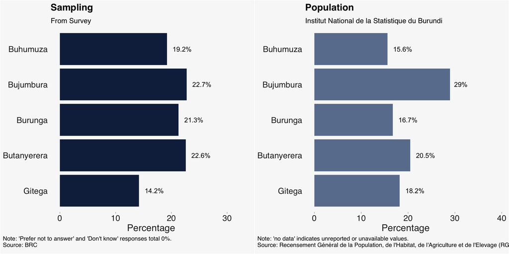

## Coverage

[interactive chart not shown]

## Gender and Age

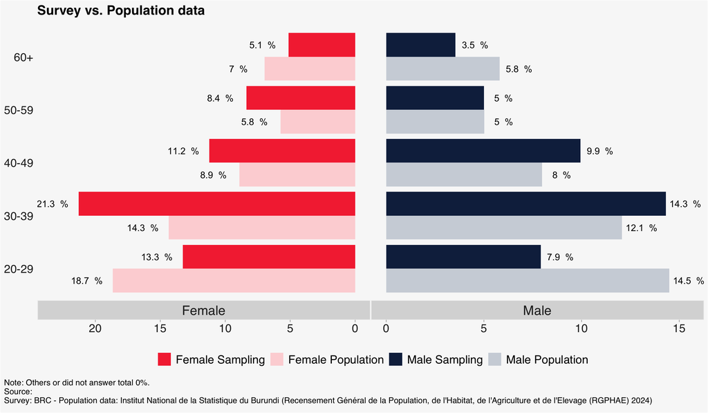

## Education

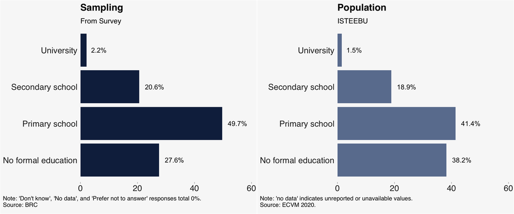

# Survey Results

The charts below present the survey answers as percentages, offering visualization of the Community Trust levels by subdimensions. They illustrate the distribution of community’s perceptions of the competencies and values.

## Perception of trust

### Competencies

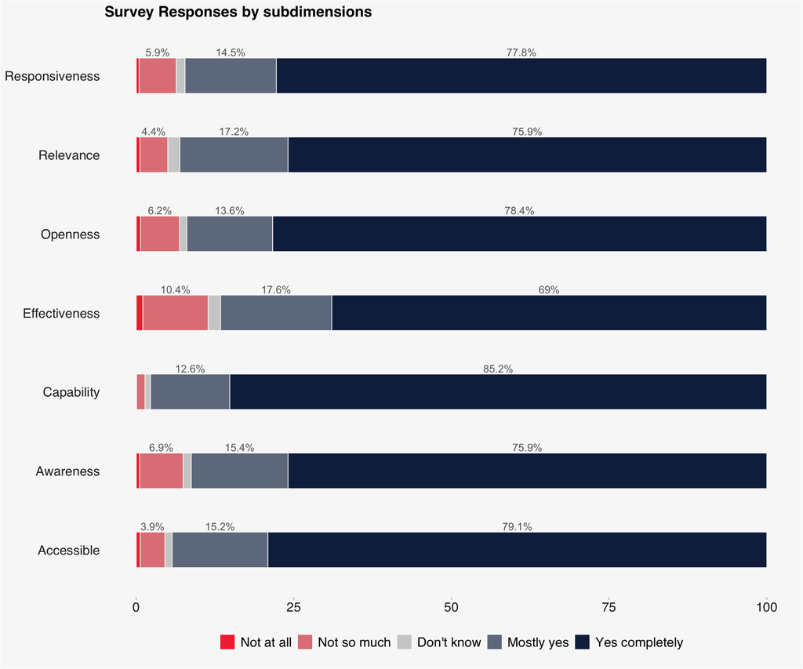

### Values

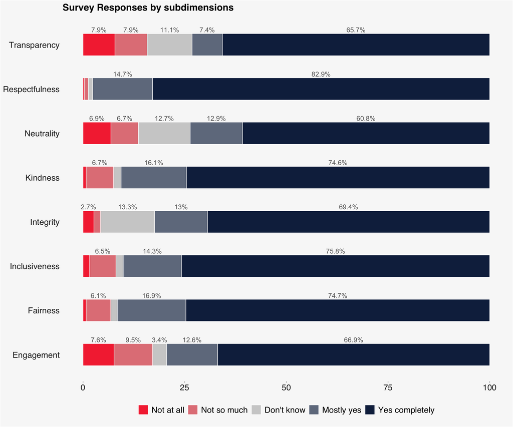

## Contextual questions

This section presents findings on community members’ experiences with and behaviors toward the Red Cross. These questions explore interactions, perceptions, and engagement patterns, offering insights into how the Red Cross is viewed and utilized within the community.

### Experiences

[figure not shown]

### Behaviours

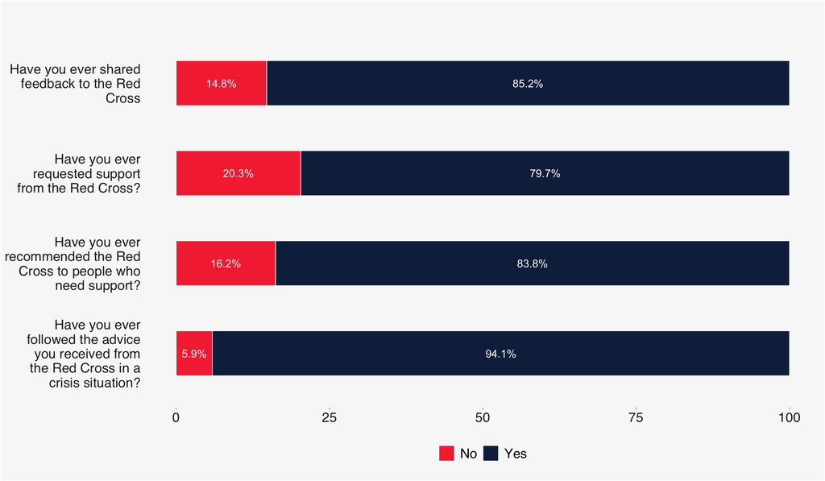

### Intention

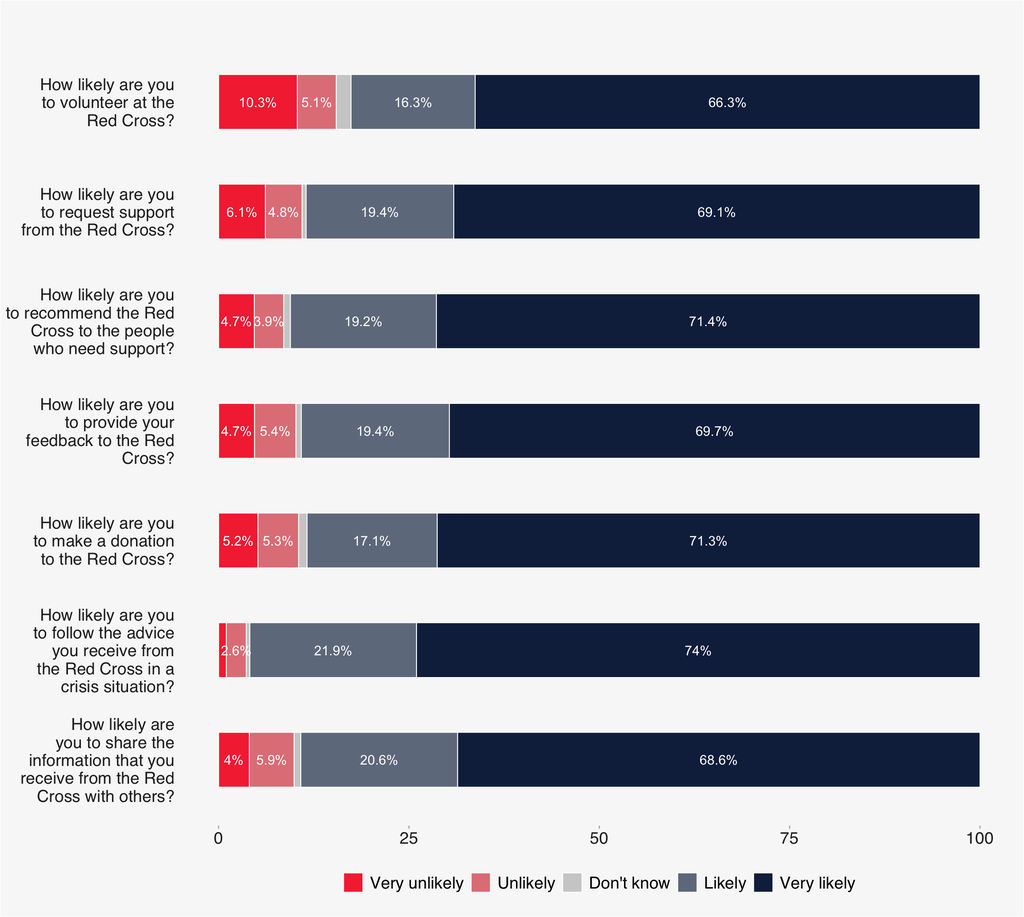

# Scores

This score is derived from responses to questions that assess perceptions of competencies and values, providing a comprehensive measure of trust. A higher score indicates stronger trust, suggesting that community members believe their needs are being addressed and their values are respected. *Learn more about scoring method: Methods*

## Overall Score

The Burundian Red Cross receives consistently high ratings across all competency and value dimensions. Capability and respectfulness are the strongest-performing areas, while engagement and transparency present the greatest opportunities for improvement.

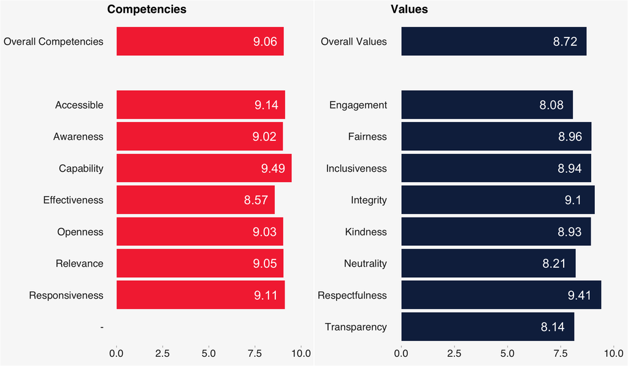

## Score by factors

Perceptions of the Burundian Red Cross are consistently positive across demographic, geographic, and engagement groups. Competency and value scores are generally high, with only modest variation between subgroups, indicating a strong and broadly shared level of trust across the surveyed population.

*Distribution of mean scores for values and competencies per demographic questions*

[figure not shown]

## Score by respondent profile

Competency and value perceptions remain consistently high across engagement groups. Respondents who have volunteered with or previously benefited from the Burundian Red Cross tend to rate the organization slightly more positively than those without prior engagement, although trust remains strong across all groups.

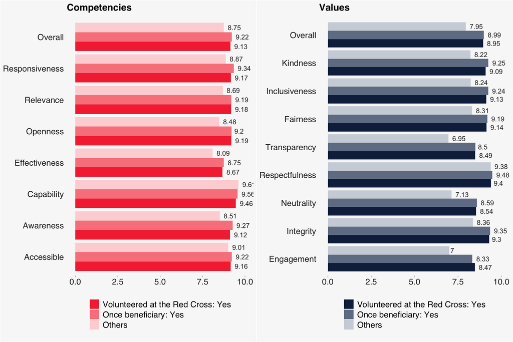

# Methods and Metrics

## Methods

**Scoring methodology**

To determine the score, we employ the following method:

1. Survey Structure The CTI survey includes multiple questions grouped under sub-dimensions of two main categories:
   - Competencies (e.g., reliability, effectiveness, technical proficiency)
   - Values (e.g., ethics, integrity, fairness, transparency)
2. Sub-Dimension Scoring

   Each sub-dimension comprises several survey items (questions).Respondents answer on a Likert-type scale (1 to 4 - Don’t not is excluded). For each sub-dimension:

   *Sub-dimension Score = ∑ (Weighted Response Scores) / Number of Items*

If weights are not empirically derived, equal weighting is typically applied to each item.

3. Dimension Scoring

Once all sub-dimension scores are calculated, the Competency Score and Values Score are each derived as the arithmetic mean of their respective sub-dimension scores:

- *Competency Score = ∑(Sub-dimension Scores for Competency) /𝑛*
- *Values Score = ∑(Sub-dimension Scores for Values)/𝑚*

where 𝑛 and 𝑚 are the number of sub-dimensions in each category.

4. Overall Scoring

   The final Community Trust Index score is the arithmetic mean of the Competency and Values scores:
- *CTI Score = (Competency Score + Values Score)/2*

## Metrics

### Gender

Respondents by Gender

| Gender | Total Respondents | Percentage (%) |
| --- | --- | --- |
| Female | 1019 | 59.3 |
| Male | 700 | 40.7 |
| Other or did not answer | 0 | 0.0 |
| Total | 1719 | 100.0 |

### Age group

Respondents by Age

| Age Group | Total Respondents | Percentage (%) |
| --- | --- | --- |
| 20-29 | 364 | 21.2 |
| 30-39 | 612 | 35.6 |
| 40-49 | 364 | 21.2 |
| 50-59 | 230 | 13.4 |
| 60+ | 149 | 8.7 |
| Total | 1719 | 100.0 |

### Geographic

Province and Commune

| Admin1 | Admin2 | Total Respondents | Percentage (%) |
| --- | --- | --- | --- |
| Buhumuza | TOTAL | 330 | 100.0 |
| Buhumuza | Butihinda | 190 | 57.6 |
| Buhumuza | Gisuru | 140 | 42.4 |
| Bujumbura | TOTAL | 391 | 100.0 |
| Bujumbura | Mpanda | 160 | 40.9 |
| Bujumbura | Bukinanyana | 129 | 33.0 |
| Bujumbura | Muhuta | 54 | 13.8 |
| Bujumbura | Rwibaga | 48 | 12.3 |
| Burunga | TOTAL | 366 | 100.0 |
| Burunga | Nyanza | 202 | 55.2 |
| Burunga | Makamba | 164 | 44.8 |
| Butanyerera | TOTAL | 388 | 100.0 |
| Butanyerera | Kayanza | 134 | 34.5 |
| Butanyerera | Matongo | 131 | 33.8 |
| Butanyerera | Tangara | 121 | 31.2 |
| Butanyerera | Kirundo | 1 | 0.3 |
| Butanyerera | Muhanga | 1 | 0.3 |
| Gitega | TOTAL | 244 | 100.0 |
| Gitega | Gishubi | 99 | 40.6 |
| Gitega | Nyabihanga | 82 | 33.6 |
| Gitega | Kiganda | 62 | 25.4 |
| Gitega | Gitega | 1 | 0.4 |

## Weighting

**Weighting vs. unweighting**

To correct demographic deviations from the overall population, we applied a technique called raking. This method adjusts results based on variables such as age, gender, province, education level, and geographic (urban/rural) to align the sample with the population distribution.

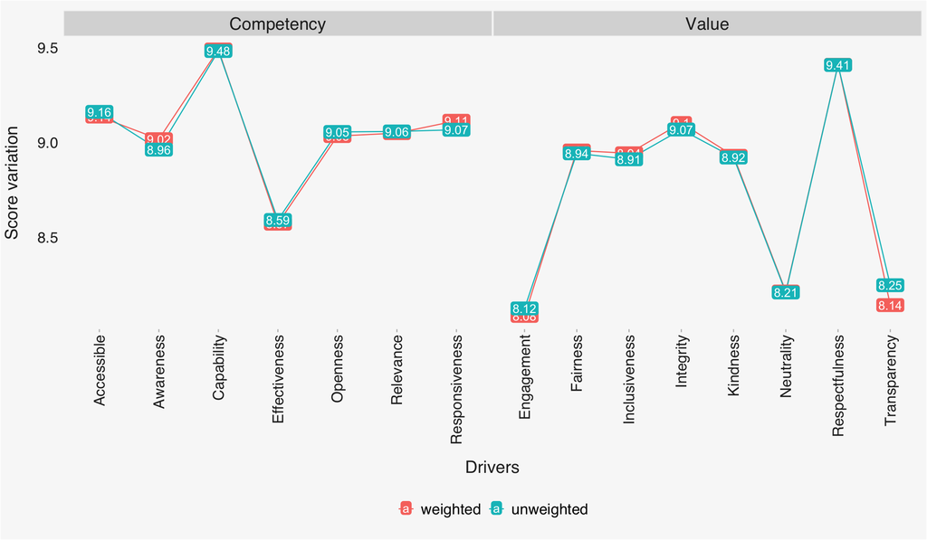

## Correlation

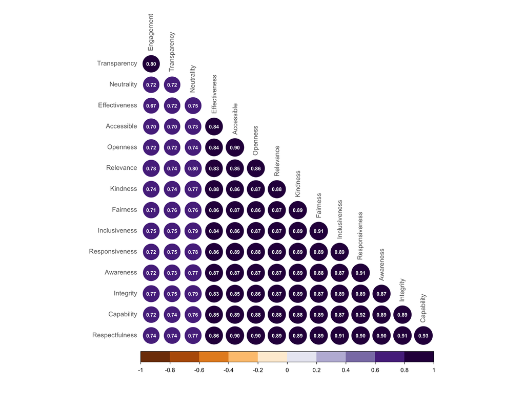

**How to read the correlation matrix**:

1. Find the row and column

2. Read the number inside the circle

Values range from –1 to +1

**Interpretation**:

| Value | Meaning |
| --- | --- |
| 0.00 | No relationship |
| 0.10–0.30 | Weak |
| 0.30–0.50 | Mild |
| 0.50–0.70 | Moderate |
| 0.70–1.00 | Strong |
| Negative values | Variables move in opposite directions |

## Significance testing

# Download

Download Summary Excel File